# Project Report: COVID-19 Analysis in Mexico

DATA 602: Statistical Data Analysis

Kanwarpal Singh (30232373), Faiq Mohd Zulkarnain (30207865), Osama Bilgrami (30213085), Arteen Rafiei (30043409)

### **Introduction**

Following the tremendous challenges posed by the COVID-19 pandemic, humanity has reached an important turning point in history, compelled to investigate, and comprehend the complexities of pandemics and their far-reaching implications. As we enter an era where the possibility of future pandemics looms large, it is critical that we strengthen our readiness and response processes. To that purpose, we are doing two independent but interconnected statistical analyses that have the potential to dramatically improve our capacity to predict the consequences of such events, similar to the COVID-19 pandemic.

The fundamental goal of our analytical efforts is to reach conclusions that will allow us to delve deeper into the complex effects of pandemics on various aspects of human existence. Our primary focus is on the investigation of crucial characteristics such as age, habits, and comorbidities, which have emerged as critical determinants in the evolution and outcome of pandemics. We hope to untangle the deep link between these parameters and the trajectory of pandemic-related outcomes through careful investigation and synthesis of multiple data sources.

Our first statistical test delves into hypothesis testing. Here, we aim to determine whether individuals aged 60 and older experience a more significant impact and higher mortality rates in comparison to those aged 18 and below due to COVID. In this context, our null hypothesis asserts that there is no difference in the proportion of COVID-related deaths between individuals above 60 and those below 18, with the difference being equal to 0. Conversely, our alternative hypothesis suggests that the mean difference is greater than 0, indicating a higher impact and mortality rate among the elderly.

In our second statistical test, we focus on investigating potential associations between an individual’s number of pre-existing health conditions and various aspects of COVID. This includes examining the likelihood of testing positive for the virus and mortality. Moreover, we aim to explore how comorbidities interact with factors such as age and gender. The objective here is to unveil the relationships and dependencies that exist between these variables.

The findings of these statistical investigations are not only significant in and of themselves, but also have implications for healthcare and policy. They have the potential to serve as the foundation for developing more targeted and effective response tactics. We hope to provide vital information to government officials, healthcare professionals, and policymakers by identifying the persons most vulnerable to the negative impacts of pandemics. In doing so, we hope to give them the skills they need to make informed decisions, allocate resources wisely, and prioritize treatments for individuals who are at a higher risk than others.

### **Dataset**

The dataset, generously provided by the Mexican government, has been made accessible on Kaggle and has been licensed as a CC0 Public Domain License, allowing users unrestricted utilization. Translated by a Kaggle user, this semi-structured dataset boasts 1,048,576 unique rows and 21 features encompassing anonymized patient-related information, including pre-existing conditions. The data exhibit a predominantly boolean format, utilizing 0 to denote male and 1 for female. Similarly, pre-existing conditions are also encoded as boolean values, with 0 signifying an absence and 1 indicating a presence.

### **Data Cleaning & Wrangling**

```
##   usmer medical_unit    sex patient_type  date_died intubed pneumonia age
## 1     2            1 female            0 03/05/2020      NA         1  65
## 2     2            1   male            0 03/06/2020      NA         1  72
## 3     2            1   male            1 09/06/2020       1         0  55
## 4     2            1 female            0 12/06/2020      NA         0  53
## 5     2            1   male            0 21/06/2020      NA         0  68
##   pregnant diabetes copd asthma inmsupr hipertension other_disease
## 1        0        0    0      0       0            1             0
## 2       NA        0    0      0       0            1             0
## 3       NA        1    0      0       0            0             0
## 4        0        0    0      0       0            0             0
## 5       NA        1    0      0       0            1             0
##   cardiovascular obesity renal_chronic tobacco clasiffication_final icu
## 1              0       0             0       0                    3  NA
## 2              0       1             1       0                    5  NA
## 3              0       0             0       0                    3   0
## 4              0       0             0       0                    7  NA
## 5              0       0             0       0                    3  NA
##   age_range number_of_disease mortality covid_test_result covid_severity
## 1     50-70                 2      Dead          Positive            Low
## 2       70+                 3      Dead          Negative       Negative
## 3     50-70                 1      Dead          Positive            Low
## 4     50-70                 0      Dead          Negative       Negative
## 5     50-70                 2      Dead          Positive            Low
```

### **Data Analysis**

#### *Initial Exploratory Data Analysis*

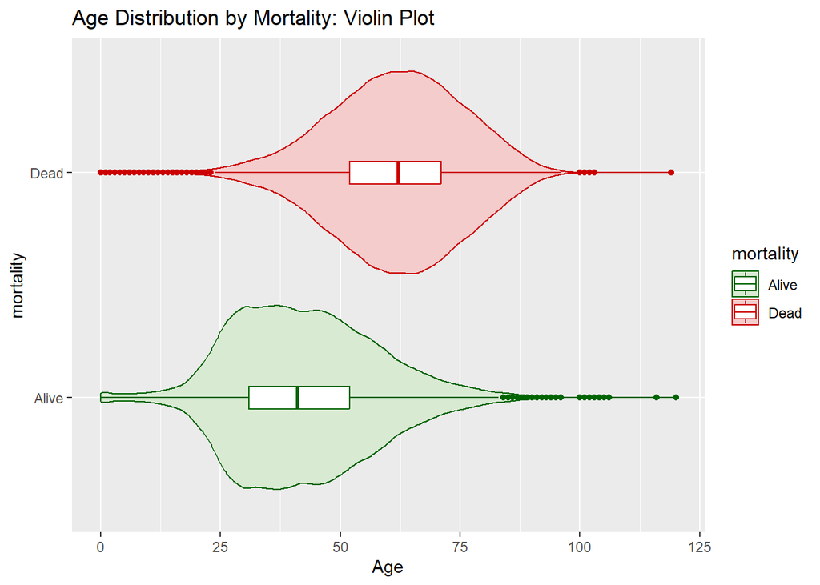

This violin plot illustrates the distribution of ages for two groups: those who are “Alive” and those who are “Dead”. The width of each violin represents the density of data points at a given age. In summary, living individuals in this dataset tend to be younger, mostly between 25-50, while deceased individuals were mostly aged between 50-75 when they passed away.

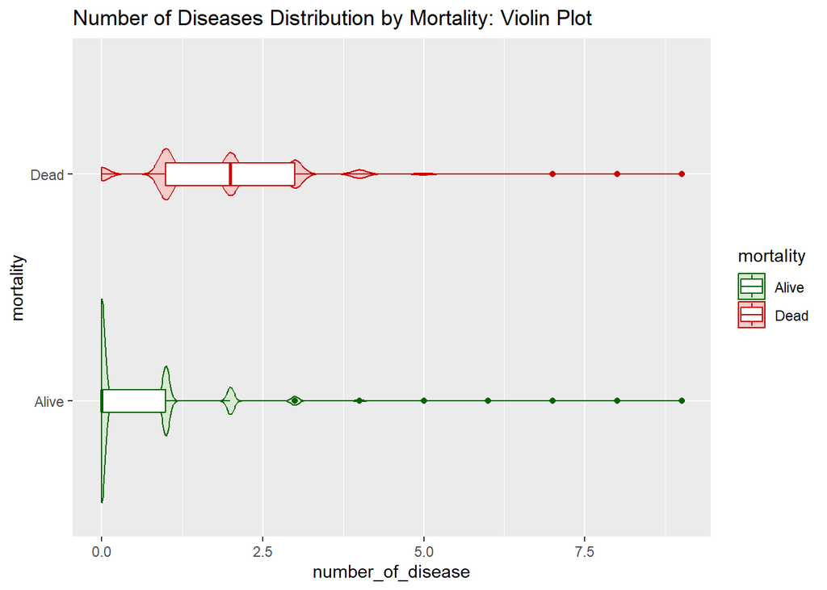

The violin plot showcases the distribution of the number of diseases among individuals based on their mortality status. Living individuals (in green) primarily have zero diseases, with a small distribution around one disease. In contrast, deceased individuals (in red) display a more spread-out distribution, primarily around one to three diseases, with some having up to around eight diseases.

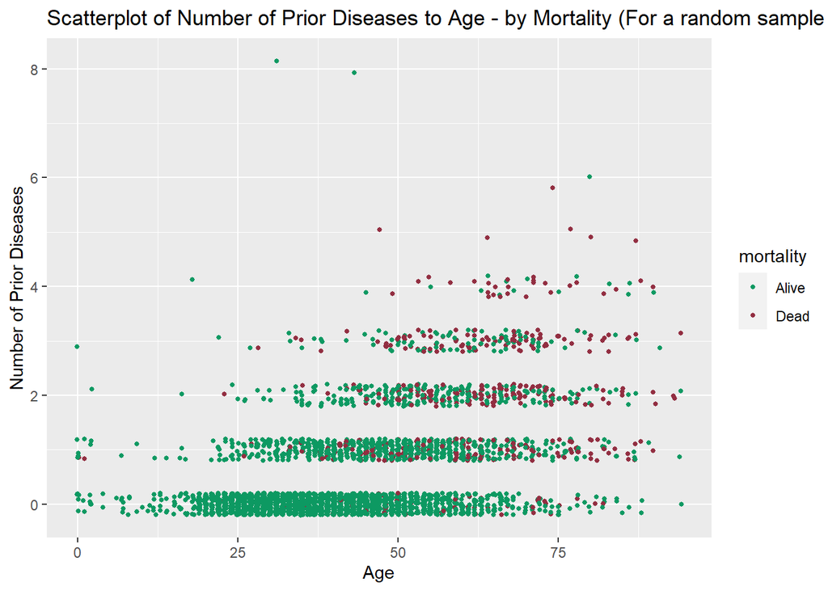

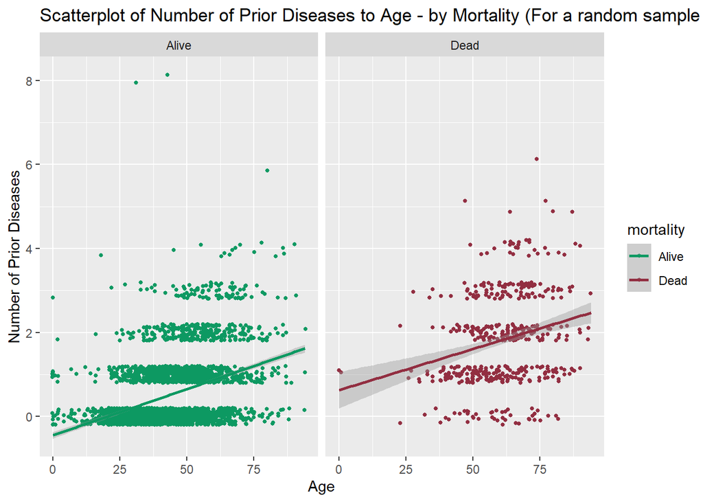

#### *1st Statistical Test - Hypothesis Testing*

$$\rm H_0: P_{Age \geq 60} - P_{Age \leq 18} = 0
\\
\rm H_A: P_{Age \geq 60} - P_{Age \leq 18} > 0$$

In order to test the stated null hypothesis we will conduct a 2-sample test for equality of proportions without continuity correction via a prop.test() to check if the proportions of deaths among the different age groups are the same.

We start by focusing on data from people who have actually tested positive for COVID-19 and break it down further to look closely at different age groups: one for seniors aged 60 and over, and another for kids and teens under 18. By doing this step-by-step, we’re making special sets of data just for these particular age groups among those who have caught the virus. This way, we can really zero in on what’s happening with the oldest and youngest folks who are dealing with COVID-19, giving us a clearer picture within the larger group of everyone who’s tested positive.

```r
sub_df_pos = df %>% filter(covid_test_result == 'Positive')
sub_df_60 = sub_df_pos %>% filter(age >= 60)
sub_df_18 = sub_df_pos %>% filter(age <= 18)
```

*Prop-Test*

```r
prop.test(c(x.age_60, x.age_18), c(n.age_60, n.age_18), alternative='two.sided', correct=FALSE)
```

```
##
##  2-sample test for equality of proportions without continuity correction
##
## data:  c out of cx.age_60 out of n.age_60x.age_18 out of n.age_18
## X-squared = 6491, df = 1, p-value < 0.00000000000000022
## alternative hypothesis: two.sided
## 95 percent confidence interval:
##  0.3801871 0.3886265
## sample estimates:
##     prop 1     prop 2
## 0.40220196 0.01779514
```

Test Results \ P-value: 0.0000 \ 95% confidence interval: [0.3801, 0.3886]

We are able to compute $P$-value of $2.2 \times e^{-16}$, which is the lowest possible $P$-value. This value being less than the level of significance of 0.05 implies a rejection of the null hypothesis.

Thanks to our large dataset, the prop.test() also computes a compact and accurate 95% confidence interval of [0.3801, 0.3886].

Therefore, based on the data, we can infer that the proportion of COVID deaths among the 60+ age group is significantly higher than the under 18 age group. Furthermore, we can be 95% confident that the proportion of 60+ COVID deaths is greater than the sub 18 age group by 0.3801-0.3886. This encompasses the observed difference in mortality rates of 0.3844.

Calculating the actual/observed difference in COVID mortality rates of individuals 60 and over and individuals 18

```r
actual.60_18 = (x.age_60 / n.age_60) - (x.age_18 / n.age_18)
actual.60_18
```

```
## [1] 0.3844068
```

To get a better picture of this confidence interval we have also decided to compute a 95% confidence interval via bootstrapping.

The following shows a distribution for 1000 bootstraps difference in mortality rate:

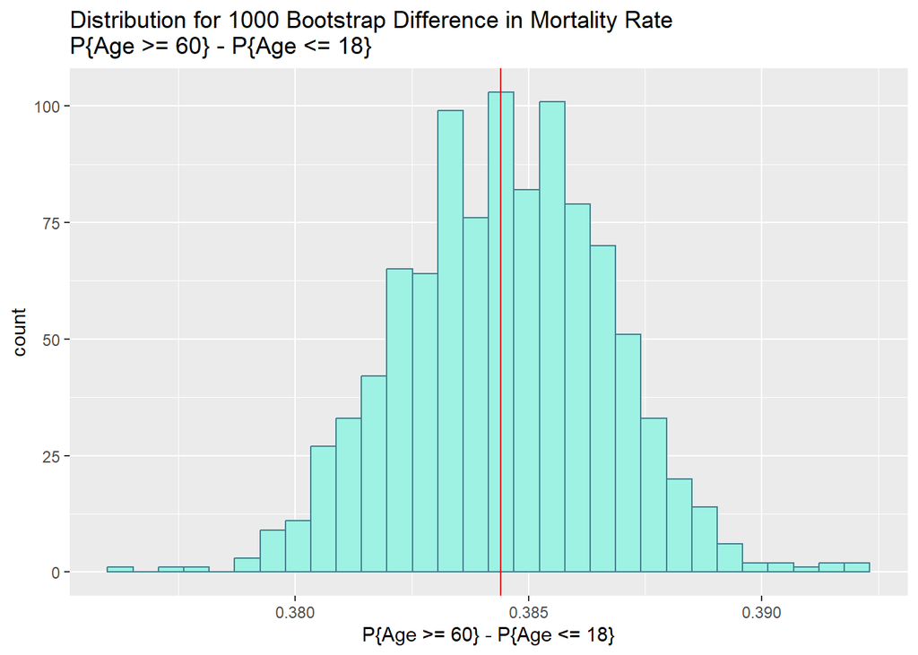

With this bootstrap method we can determine the 95% confidence intervals for difference in proportions of mortality rates, mortality rates of the 60+ age group and sub 18 age group.

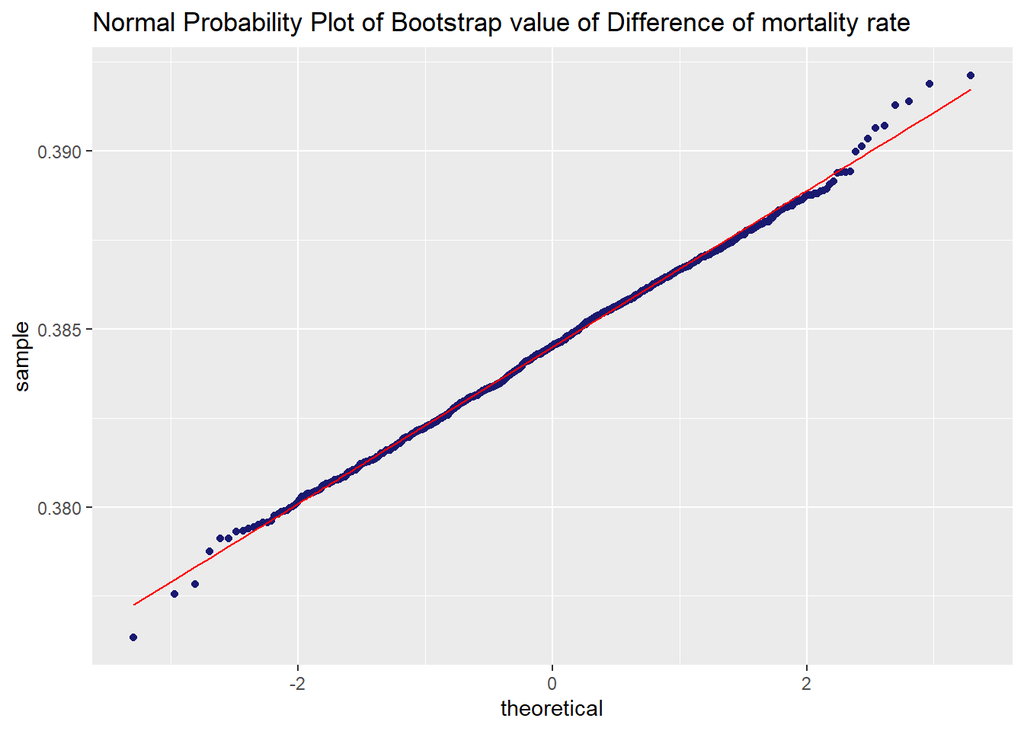

Based on a probability plot of differences computed, it appears to follow a normal distribution as the data points in this plot are located approximately along a straight line, it can be concluded that the selected distribution correctly represents the data.

**95% confidence interval for Difference between** $P_{Age \geq 60} - P_{Age \leq 18}$

```r
qdata(~phat.60_18, c(0.025,0.975), data=phat.60_18.df)
```

```
##      2.5%     97.5%
## 0.3802965 0.3886169
```

Based on this 95% confidence interval via bootstrapping we can be 95% confident that the difference in COVID mortality rates of individuals 60 and over and individuals 18 and under is between 0.3802 and 0.3886. This reaffirms the outcome obtained from the prop.test previously conducted and the observed difference of 0.3844.

**95% confidence interval for** $P_{Age \geq 60}$

```r
qdata(~phat.60, c(0.025,0.975), data=phat.60_18.df)
```

```
##      2.5%     97.5%
## 0.3986611 0.4056518
```

Based on this 95% confidence interval via bootstrapping we can be 95% confident that the COVID mortality rate of individuals 60 and over is between 0.3986 and 0.4056. This confidence interval encompasses the observed mortality rate of 31015/77113 = 0.4022.

**95% confidence interval for** $P_{Age \leq 18}$

```r
qdata(~phat.18, c(0.025,0.975), data=phat.60_18.df)
```

```
##       2.5%      97.5%
## 0.01527561 0.02031250
```

Based on this 95% confidence interval via bootstrapping we can be 95% confident that the COVID mortality rate of individuals 18 and under is between 0.0153 and 0.0203. This confidence interval encompasses the observed mortality rate of 205/11520 = 0.0178.

Here we can visualize the differences in mortality rates between the different age groups.

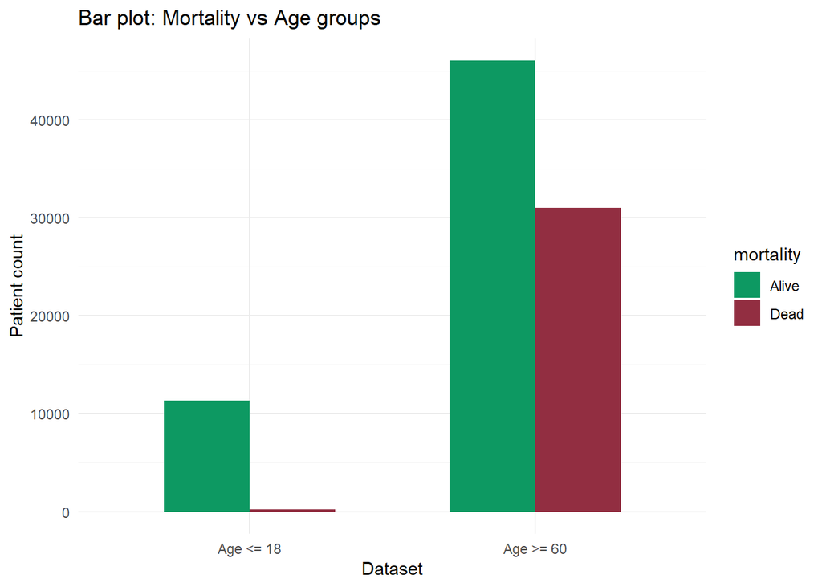

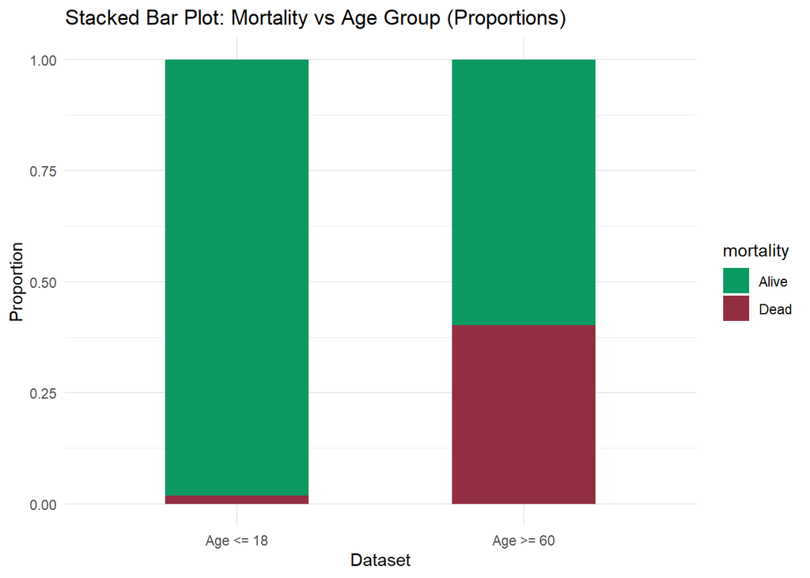

#### *2nd Statistisal Test - Chi-squared Test of Independence*

$$\rm H_0: \text{Co-Morbidities and the factors of interest are
independent}
\\
\rm H_A: \text{Co-Morbidities and the factors of interest are dependent}$$

As COVID has been heavily associated with co-morbidities, we want to determine if there is any correlation between the number of diseases among an individual and COVID attributes such as whether someone will test positive for COVID and mortality. We will also explore the correlation of co-morbidities with age and gender.

**First let’s take a look at whether a correlation exists between number of diseases among an individual and status (testing positive for COVID)**

$$\rm H_0: \text{Number of Disease an individual has and their Covid Test
Result are independent}
\\
\rm H_A: \text{Number of Disease an individual has and their Covid Test
Result are not independent}$$

Contingency Table

```
##                  covid_test_result
## number_of_disease Positive Negative
##                 0      105      227
##                 1       56       48
##                 2       15       29
##                 3        8        5
##                 4        2        4
##                 7        0        1
```

Chisq Result

```
##
##  Pearson's Chi-squared test with simulated p-value (based on 2000
##  replicates)
##
## data:  covid_test
## X-squared = 20.859, df = NA, p-value = 0.001499
```

Given the $P$-value of 0.001499 being less than the significance level of 0.05, we reject the null hypothesis. This means that based on the COVID sample data, there is enough evidence to suggest a significant association between the number of diseases an individual has and their likelihood of testing positive for COVID.

We can visualize the COVID test results based on the number of diseases as shown here.

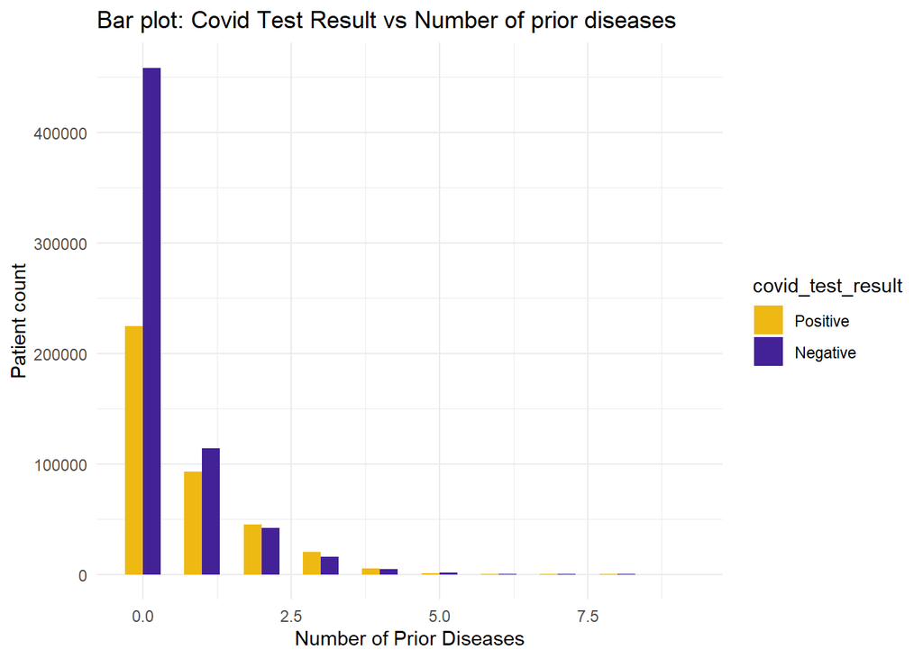

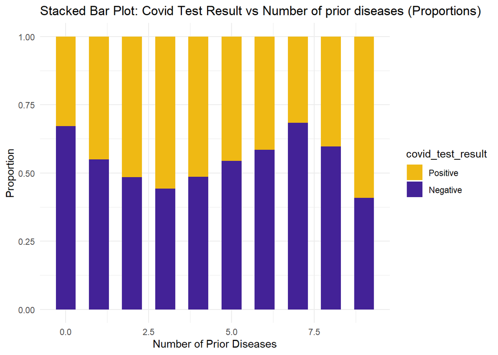

**We take a look at whether a correlation exists between the number of prior diseases among an individual and the severity of COVID symptoms**

$$\rm H_0: \text{Number of Disease an individual has and Severity of COVID
Symptoms are independent}
\\
\rm H_A: \text{Number of Disease an individual has and Severity of COVID
Symptoms are not independent}$$
Contingency Table

```
##                  covid_severity
## number_of_disease High Medium Low
##                 0   10      1 271
##                 1    2      2 113
##                 2    1      2  59
##                 3    2      0  27
##                 4    0      0  10
```

Chisq Result

```
##
##  Pearson's Chi-squared test with simulated p-value (based on 2000
##  replicates)
##
## data:  severity
## X-squared = 8.3713, df = NA, p-value = 0.3393
```

We can visualize the COVID Severity based on the number of diseases as shown here.

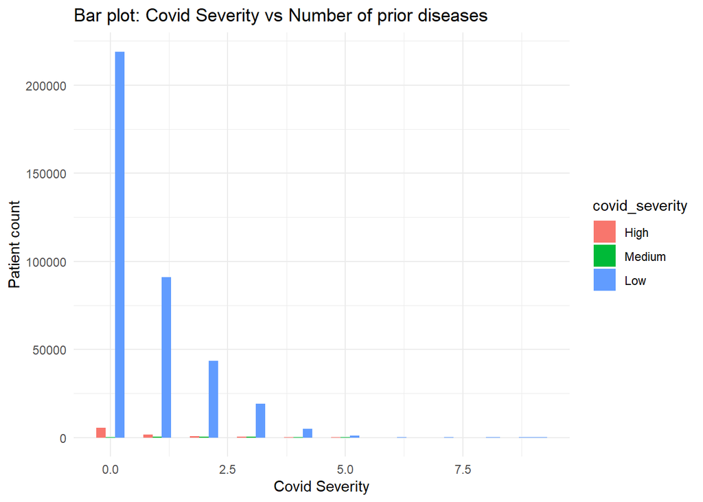

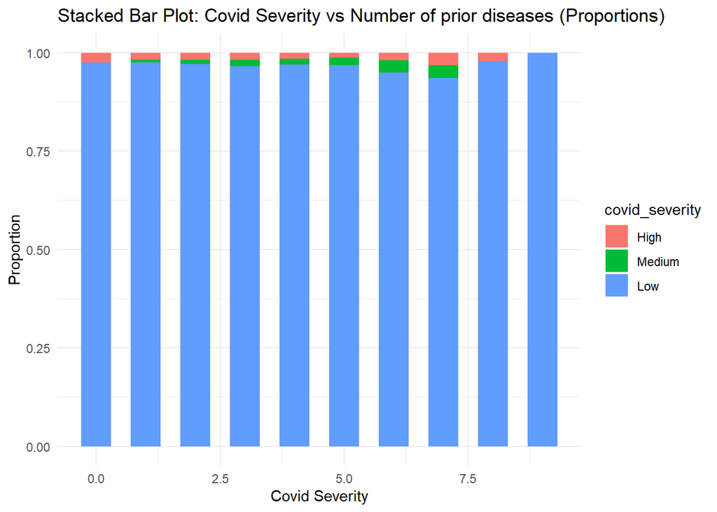

**We examine whether there is a correlation between the number of previous diseases in an individual and their Mortality Rate.**

$$\rm H_0: \text{Number of Disease an individual has and Mortality are
independent}
\\
\rm H_A: \text{Number of Disease an individual has and Mortality are not
independent}$$
Contingency Table

```
##                  mortality
## number_of_disease Alive Dead
##                 0   303    5
##                 1    90   20
##                 2    34   21
##                 3    12    9
##                 4     2    2
##                 5     0    2
```

Chisq Result

```
##
##  Pearson's Chi-squared test with simulated p-value (based on 2000
##  replicates)
##
## data:  mortality
## X-squared = 111.75, df = NA, p-value = 0.0004998
```

The computed $P$-value of 0.0004998 is also well below the 0.05 significance level threshold. This leads to the conclusion that we would reject the null hypothesis. Thus, based on the COVID data, there is a statistically significant association between the number of diseases an individual has and their mortality. The number of diseases and mortality are not independent; there exists a relationship between them.

We can visualize the Mortality based on the number of diseases as shown here.

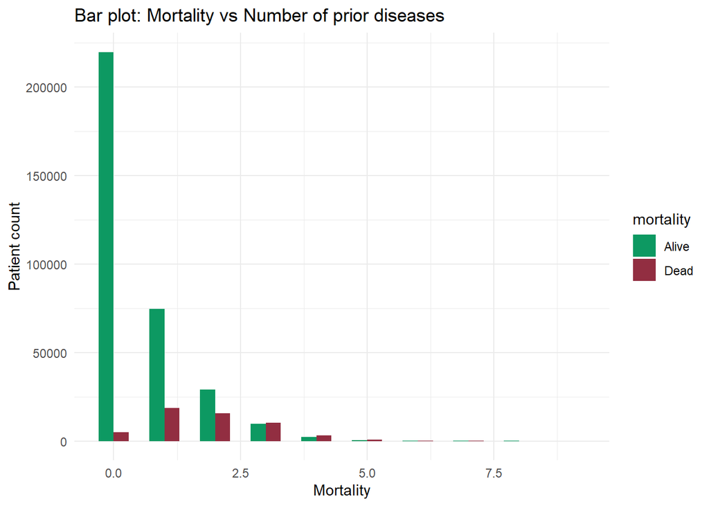

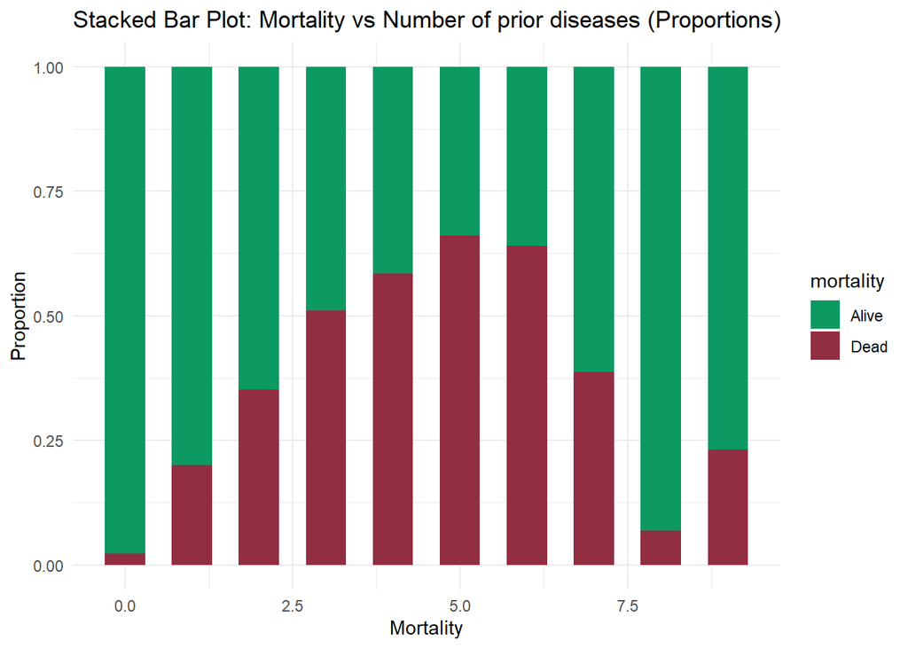

**Now, we check whether there is a correlation between the number of prior diseases among an individual and the Age range they belong to**

$$\rm H_0: \text{Number of Disease an individual has and their Age Group
are independent}
\\
\rm H_A: \text{Number of Disease an individual has and their Age Group
are not independent}$$
Contingency Table

```
##                  age_range
## number_of_disease 0-13 14-19 20-35 36-49 50-70 70+
##                 0    6    12   108   103    60   7
##                 1    1     1    17    44    54   5
##                 2    0     0     5    11    26  13
##                 3    0     0     0     1    12   8
##                 4    0     0     0     1     2   1
##                 5    0     0     0     0     2   0
```

Chisq Result

```
##
##  Pearson's Chi-squared test with simulated p-value (based on 2000
##  replicates)
##
## data:  age_range
## X-squared = 145.82, df = NA, p-value = 0.0009995
```

Given the $P$-value is 0.0009995, which is well below the significance level of 0.05, we would reject the null hypothesis. This means that based on the COVID sample data, there is a statistically significant association between the number of diseases an individual has and their age group. In other words, age group and the number of diseases are not independent; there is a relationship between them.

Here is a visualization that shows the counts and proportions of different age ranges and the number of diseases an individual has among those age groups.

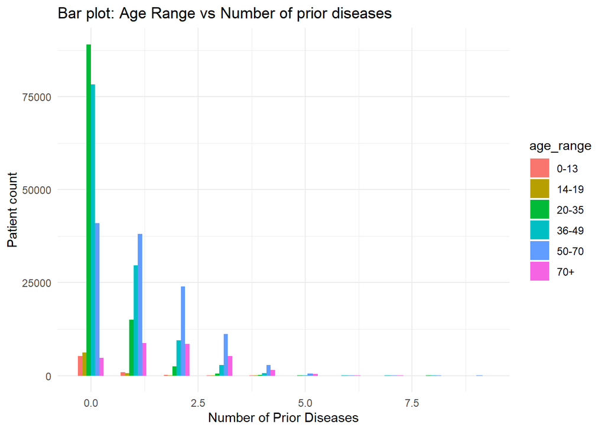

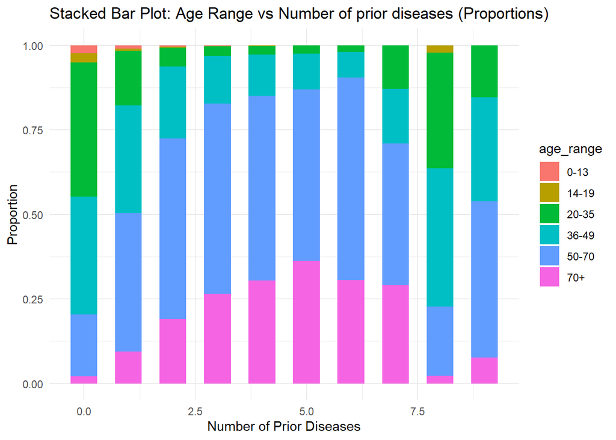

**Finally, let’s take a look at whether a correlation exists between number of prior diseases among an individual and their Gender**

$$\rm H_0: \text{Number of Disease an individual has and their Gender is
independent}
\\
\rm H_A: \text{Number of Disease an individual has and their Gender is
not independent}$$
Contingency Table

```
##                  sex
## number_of_disease female male
##                 0    134  154
##                 1     61   56
##                 2     21   28
##                 3     17   20
##                 4      3    1
##                 5      2    2
##                 9      1    0
```

Chisq Result

```
##
##  Pearson's Chi-squared test with simulated p-value (based on 2000
##  replicates)
##
## data:  sex
## X-squared = 3.8853, df = NA, p-value = 0.7216
```

Given the $P$-value of 0.7216 being more than the significance level of 0.05, we fail to reject the null hypothesis. This means that based on the COVID sample data, there is not enough evidence to suggest a significant association between the number of diseases an individual has and their gender.

Here is a visualization that shows the counts and proportions of Gender and the number of diseases an individual has.

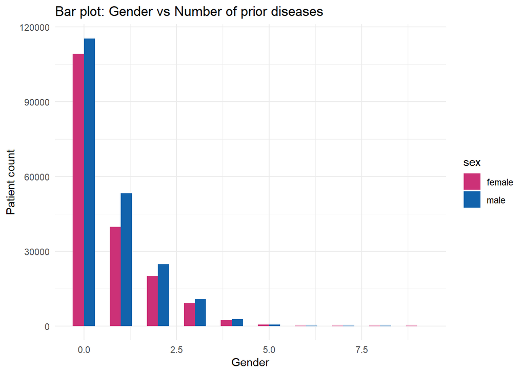

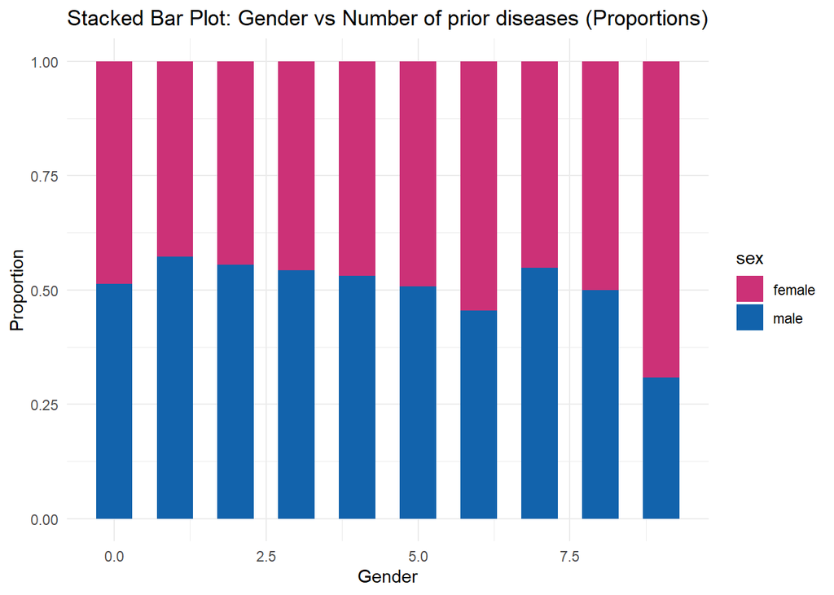

### **Conclusion**

The findings from both traditional proportion tests and bootstrap methods indicate that individuals aged 60 and above have a significantly higher mortality rate due to COVID-19 compared to individuals aged 18 and under. Both tests reaffirm the observed differences within the dataset thanks to the tight 95% confidence intervals.

To generate more realistic insights, we reproduced our studies by analyzing 500 random data points. While the majority of the results were similar to those obtained from assessments of the complete dataset, several variations led to different conclusions. Notably, our investigation indicated that severity and gender appeared to be uncorrelated with comorbidities. This finding, based on our sample approach, lends credence to the claim that it constitutes a more accurate conclusion. As we have seen, the large size of the dataset can make Chi-square tests prone to consistently identify relationships. This assumption is supported by the graphical representation, which clearly indicates independence between gender and comorbidities, as well as between comorbidities and severity. Consequently, our findings support the notion that employing a sampling approach may enhance the accuracy of Chi-square tests, particularly in contexts where the sensitivity of these tests in large datasets can inadvertently indicate relationships.

Our study underscores the profound impact of age and comorbidities on COVID-19 outcomes, emphasizing the need for targeted interventions, especially for older individuals and those with multiple diseases.

### **References**

- Loza, A., Wong-Chew, R. M., Jiménez-Corona, M.-E., Zárate, S., López, S., Ciria, R., Palomares, D., García-López, R., Iša, P., Taboada, B., Rosales, M., Boukadida, C., Herrera-Estrella, A., Mojica, N. S., Rivera-Gutierrez, X., Muñoz-Medina, J. E., Salas-Lais, A. G., Sanchez-Flores, A., Vazquez-Perez, J. A., … Gutiérrez-Ríos, R. M. (2023). Two-year follow-up of the COVID- 19 pandemic in Mexico. Frontiers in Public Health, 10, 1050673.https://doi.org/10.3389/fpubh.2022.1050673
- Nizri, M. (2023). COVID-19 Dataset [Data set]. Kaggle. Retrieved October 17, 2023, from https://www.kaggle.com/datasets/meirnizri/covid19-dataset
- Secretaría de Salud (Mexico). (2023). Información referente a casos COVID-19 en México [Data set]. Gobierno de México. Retrieved October 17, 2023, from https://datos.gob.mx/busca/dataset/informacion-referente-a-casos-covid-19-en-mexico

### **Appendix: All code for this report**

```r
options(scipen=999)

library(ggplot2)
library(knitr)
library(dplyr)
library(mosaic)
set.seed(1997)
df = read.csv('coviddataset.csv')
head(df, 5)
names(df) = tolower(names(df))

#df$icu[df$icu %in% c(97, 98, 99)] = NA
df[df == 97] = NA
df[df == 98] = NA
df[df == 99] = NA

df$date_died[df$date_died == '9999-99-99'] = NA

cols_to_replace = c('sex', 'intubed', 'pneumonia', 'pregnant', 'diabetes', 'copd', 'asthma', 'inmsupr', 'hipertension', 'other_disease', 'cardiovascular', 'obesity', 'renal_chronic', 'tobacco', 'icu')

# Replace all occurrences of 2 with 0 in the specified columns
df = df %>% mutate(across(all_of(cols_to_replace), ~ifelse(. == 2, 0, .)))
df$sex[df$sex == 0] <- "male"
df$sex[df$sex == 1] <- "female"
df$patient_type[df$patient_type == 1] = 0
df$patient_type[df$patient_type == 2] = 1
breaks <- c(0, 13, 19, 35, 49, 70, 150)
labels <- c('0-13', '14-19', '20-35', '36-49', '50-70', '70+')

df$age_range <- cut(df$age, breaks = breaks, labels = labels, include.lowest = TRUE)
cols_to_sum = c('pneumonia', 'diabetes', 'copd', 'asthma', 'inmsupr', 'hipertension', 'other_disease', 'cardiovascular', 'renal_chronic')

# Create a new column 'number_of_disease' with the sum of selected columns
df = df %>% mutate(number_of_disease = rowSums(select(., all_of(cols_to_sum))))
df$mortality = ifelse(is.na(df$date_died), "Alive", "Dead")
df$covid_test_result = cut(df$clasiffication_final, breaks = c(0, 3, 8), labels = c("Positive", "Negative"))
df$covid_test_result = as.factor(df$covid_test_result)
df$covid_severity = cut(df$clasiffication_final, breaks = c(0, 1, 2, 3, 8), labels = c("High", "Medium", "Low", "Negative"))
df$covid_severity = as.factor(df$covid_severity)
head(df, 5)

ggplot(data=filter(df, (covid_test_result == "Positive")), aes(x=mortality, y=age, color = mortality, fill = mortality)) + geom_violin(na.rm=TRUE) + geom_boxplot(fill = "white", width=0.1, na.rm=TRUE) + ylab("Age") + ggtitle("Age Distribution by Mortality: Violin Plot") + scale_color_manual(values = c("Alive" = "darkgreen", "Dead" = "#cc0000")) + scale_fill_manual(values = c("Alive" = "#d9ead3", "Dead" = "#f4cccc")) + coord_flip()
ggplot(data=filter(df, (covid_test_result == "Positive")), aes(x=mortality, y=number_of_disease, color = mortality, fill = mortality)) + geom_violin(na.rm=TRUE) + geom_boxplot(fill = "white", width=0.1, na.rm=TRUE) + ylab("number_of_disease") + ggtitle("Number of Diseases Distribution by Mortality: Violin Plot") + scale_color_manual(values = c("Alive" = "darkgreen", "Dead" = "#cc0000")) + scale_fill_manual(values = c("Alive" = "#d9ead3", "Dead" = "#f4cccc")) + coord_flip()
sample_df = sample(df, 10000, replace=TRUE)
ggplot(data=filter(sample_df, (covid_test_result == "Positive")), aes(x = age, y = number_of_disease, color=mortality)) + geom_point(size=1,position = position_jitter(width = 0.2, height = 0.2)) + scale_color_manual(values = c("Alive" = "#0d9962", "Dead" = "#922e41")) + xlab("Age") + ylab("Number of Prior Diseases") + ggtitle("Scatterplot of Number of Prior Diseases to Age - by Mortality (For a random sample of 10000)")
ggplot(data=filter(sample_df, (covid_test_result == "Positive")), aes(x = age, y = number_of_disease, color=mortality)) + geom_point(size=1,position = position_jitter(width = 0.2, height = 0.2)) + scale_color_manual(values = c("Alive" = "#0d9962", "Dead" = "#922e41")) + xlab("Age") + ylab("Number of Prior Diseases") + ggtitle("Scatterplot of Number of Prior Diseases to Age - by Mortality (For a random sample of 10000)") + facet_wrap(~ mortality) + geom_smooth(method="lm")
sub_df_pos = df %>% filter(covid_test_result == 'Positive')
sub_df_60 = sub_df_pos %>% filter(age >= 60)
sub_df_18 = sub_df_pos %>% filter(age <= 18)
length(sub_df_pos$age)
n.age_60 = length(sub_df_60$mortality)
n.age_18 = length(sub_df_18$mortality)

x.age_60 = favstats(~age, data=filter(sub_df_60,mortality == "Dead"))$n
x.age_18 = favstats(~age, data=filter(sub_df_18,mortality == "Dead"))$n

n.age_60
n.age_18
x.age_60
x.age_18
prop.test(c(x.age_60, x.age_18), c(n.age_60, n.age_18), alternative='two.sided', correct=FALSE)
data.60 = c(rep(0, n.age_60-x.age_60), rep(1, x.age_60))
data.18 = c(rep(0, n.age_18-x.age_18), rep(1, x.age_18))

condition = c(rep(c(">= 60"), n.age_60), rep(c("<= 18"), n.age_18))
used = c(data.60, data.18)

mortality = data.frame(condition, used)

mortality60 = filter(mortality, condition==">= 60")
mortality18 = filter(mortality, condition=="<= 18")

phat.60 = numeric(1000)
phat.18 = numeric(1000)
phat.60_18 = numeric(1000)

for(i in 1:1000){
  phat.60[i] = sum(sample(mortality60$used, n.age_60, replace=TRUE))/n.age_60
  phat.18[i] = sum(sample(mortality18$used, n.age_18, replace=TRUE))/n.age_18

  phat.60_18[i] = phat.60[i] - phat.18[i]
}
phat.60_18.df = data.frame(phat.60, phat.18, phat.60_18)
actual.60_18 = (x.age_60 / n.age_60) - (x.age_18 / n.age_18)
actual.60_18
ggplot(phat.60_18.df, aes(phat.60_18)) + geom_histogram(col="#45818e", fill= "#9ef2e4", ) + xlab("P{Age >= 60} - P{Age <= 18}") + ggtitle("Distribution for 1000 Bootstrap Difference in Mortality Rate \nP{Age >= 60} - P{Age <= 18}") + geom_vline(xintercept = actual.60_18, col="#e40909")
ggplot(data=phat.60_18.df, aes(sample=phat.60_18)) + stat_qq(col="midnightblue") + stat_qqline(col="red") + ggtitle("Normal Probability Plot of Bootstrap value of Difference of mortality rate")
qdata(~phat.60_18, c(0.025,0.975), data=phat.60_18.df)
qdata(~phat.60, c(0.025,0.975), data=phat.60_18.df)
qdata(~phat.18, c(0.025,0.975), data=phat.60_18.df)
combined_df_60_18 = bind_rows(sub_df_60 %>% mutate(Dataset = "Age >= 60"),sub_df_18 %>% mutate(Dataset = "Age <= 18"))

head(combined_df_60_18,5)
ggplot(data = combined_df_60_18, aes(x = Dataset, fill = mortality)) +
  geom_bar( position = "dodge", width = 0.6) +
  scale_fill_manual(values = c("Alive" = "#0d9962", "Dead" = "#922e41")) +
  ylab("Patient count") +
  xlab("Dataset") +
  ggtitle("Bar plot: Mortality vs Age groups") +
  theme_minimal()
ggplot(data = combined_df_60_18, aes(x = Dataset, fill = mortality)) +
  geom_bar(position = "fill", width = 0.5) +
  scale_fill_manual(values = c("Alive" = "#0d9962", "Dead" = "#922e41")) +
  ylab("Proportion") +
  xlab("Dataset") +
  ggtitle("Stacked Bar Plot: Mortality vs Age Group (Proportions)") +
  theme_minimal()

covid_test.df = subset(df, select = c(number_of_disease,covid_test_result))
covid_test.df = covid_test.df[complete.cases(covid_test.df), ]

sample.df = sample(covid_test.df, 500, replace=TRUE)
covid_test = tally(~number_of_disease + covid_test_result, data = sample.df)
covid_test
chi1 = chisq.test(covid_test, simulate.p.value=TRUE)
chi1

p.covid_test = chi1$p.value
test_stat.covid_test = chi1$statistic

p.covid_test
test_stat.covid_test
ggplot(data = covid_test.df, aes(x = number_of_disease, fill = covid_test_result)) +
  geom_bar( position = "dodge", width = 0.6) +
  scale_fill_manual(values = c("Positive" = "#efb914", "Negative" = "#432297")) +
  ylab("Patient count") +
  xlab("Number of Prior Diseases") +
  ggtitle("Bar plot: Covid Test Result vs Number of prior diseases") +
  theme_minimal()
ggplot(data = covid_test.df, aes(x = number_of_disease, fill = covid_test_result)) +
  geom_bar(position = "fill", width = 0.6) +
  scale_fill_manual(values = c("Positive" = "#efb914", "Negative" = "#432297")) +
  ylab("Proportion") +
  xlab("Number of Prior Diseases") +
  ggtitle("Stacked Bar Plot: Covid Test Result vs Number of prior diseases (Proportions)") +
  theme_minimal()
severity.df = subset(sub_df_pos, select = c(number_of_disease, covid_severity))
severity.df = severity.df[complete.cases(severity.df), ]

sample2.df = sample(severity.df, 500, replace=TRUE)
severity = tally(~number_of_disease + covid_severity, data = sample2.df)
severity = severity[, -4]
severity
chi2 = chisq.test(severity, simulate.p.value = TRUE)
chi2
p.severity = chi2$p.value
test_stat.severity = chi2$statistic

p.severity
test_stat.severity
ggplot(data = severity.df, aes(x = number_of_disease, fill = covid_severity)) +
  geom_bar( position = "dodge", width = 0.6) +

  ylab("Patient count") +
  xlab("Covid Severity") +
  ggtitle("Bar plot: Covid Severity vs Number of prior diseases") +
  theme_minimal()
ggplot(data = severity.df, aes(x = number_of_disease, fill = covid_severity)) +
  geom_bar(position = "fill", width = 0.6) +

  ylab("Proportion") +
  xlab("Covid Severity") +
  ggtitle("Stacked Bar Plot: Covid Severity vs Number of prior diseases (Proportions)") +
  theme_minimal()
mortality.df = subset(sub_df_pos, select = c(number_of_disease, mortality))
mortality.df = mortality.df[complete.cases(mortality.df), ]

sample3.df = sample(mortality.df, 500, replace=TRUE)
mortality = tally(~number_of_disease + mortality, data = sample3.df)
mortality
chi3 = chisq.test(mortality, simulate.p.value = TRUE)
chi3

p.mortality = chi3$p.value
test_stat.mortality = chi3$statistic

p.mortality
test_stat.mortality
ggplot(data = mortality.df, aes(x = number_of_disease, fill = mortality)) +
  geom_bar( position = "dodge", width = 0.6) +
  scale_fill_manual(values = c("Alive" = "#0d9962", "Dead" = "#922e41")) +
  ylab("Patient count") +
  xlab("Mortality") +
  ggtitle("Bar plot: Mortality vs Number of prior diseases") +
  theme_minimal()
ggplot(data = mortality.df, aes(x = number_of_disease, fill = mortality)) +
  geom_bar(position = "fill", width = 0.6) +
  scale_fill_manual(values = c("Alive" = "#0d9962", "Dead" = "#922e41")) +
  ylab("Proportion") +
  xlab("Mortality") +
  ggtitle("Stacked Bar Plot: Mortality vs Number of prior diseases (Proportions)") +
  theme_minimal()
age_range.df = subset(sub_df_pos, select = c(number_of_disease, age_range))
age_range.df = age_range.df[complete.cases(age_range.df), ]

sample4.df = sample(age_range.df, 500, replace=TRUE)
age_range = tally(~number_of_disease + age_range, data = sample4.df)
age_range
chi2 = chisq.test(age_range, simulate.p.value = TRUE)
chi2

p.age_range = chi2$p.value
test_stat.age_range = chi2$statistic

p.age_range
test_stat.age_range
ggplot(data = age_range.df, aes(x = number_of_disease, fill = age_range)) +
  geom_bar( position = "dodge", width = 0.6) +

  ylab("Patient count") +
  xlab("Number of Prior Diseases") +
  ggtitle("Bar plot: Age Range vs Number of prior diseases") +
  theme_minimal()
ggplot(data = age_range.df, aes(x = number_of_disease, fill = age_range)) +
  geom_bar(position = "fill", width = 0.6) +

  ylab("Proportion") +
  xlab("Number of Prior Diseases") +
  ggtitle("Stacked Bar Plot: Age Range vs Number of prior diseases (Proportions)") +
  theme_minimal()
sex.df = subset(sub_df_pos, select = c(number_of_disease, sex))
sex.df = sex.df[complete.cases(sex.df), ]

sample5.df = sample(sex.df, 500, replace=TRUE)
sex = tally(~number_of_disease + sex, data = sample5.df)
sex
chi4 = chisq.test(sex, simulate.p.value = TRUE)
chi4

p.sex = chi4$p.value
test_stat.sex = chi4$statistic

p.sex
test_stat.sex
ggplot(data = sex.df, aes(x = number_of_disease, fill = sex, group = sex)) +
  geom_bar( position = "dodge", width = 0.6) +
  scale_fill_manual(values = c("female" = "#cc3177", "male" = "#1263ac")) +
  ylab("Patient count") +
  xlab("Gender") +
  ggtitle("Bar plot: Gender vs Number of prior diseases") +
  theme_minimal()
ggplot(data = sex.df, aes(x = number_of_disease, fill = sex, group = sex)) +
  geom_bar(position = "fill", width = 0.6) +
  scale_fill_manual(values = c("female" = "#cc3177", "male" = "#1263ac")) +
  ylab("Proportion") +
  xlab("Gender") +
  ggtitle("Stacked Bar Plot: Gender vs Number of prior diseases (Proportions)") +
  theme_minimal()
```